# Exploratory Data Analysis for Video Game Development Companies Ryan Reiser

## Displays commonly used descriptive statistics such as mean, minimum, and maximum for the price logarithmic returns for each company over the timeline

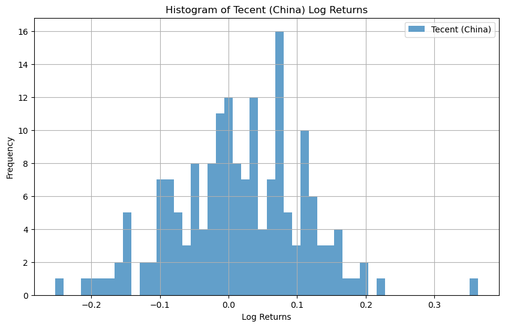

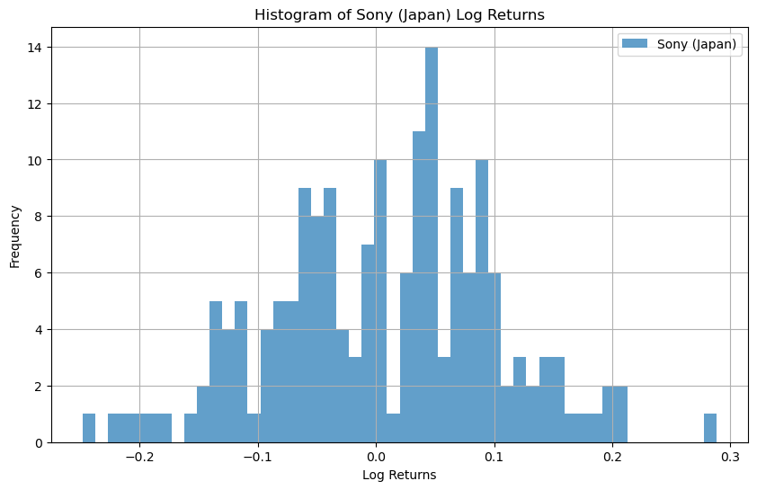

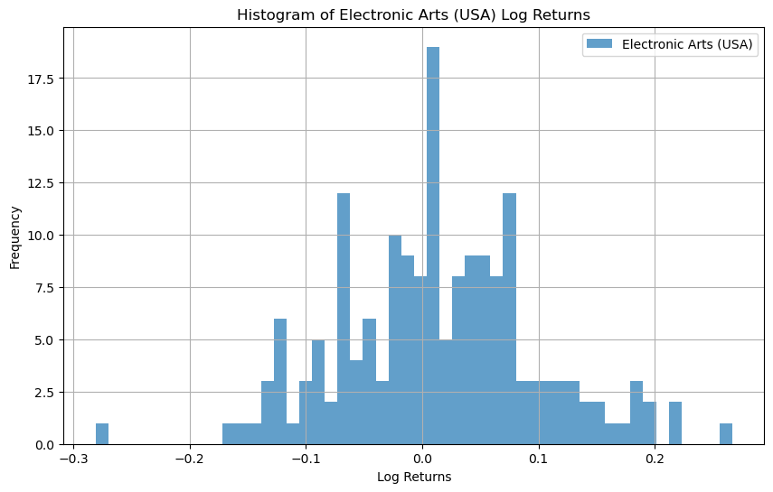

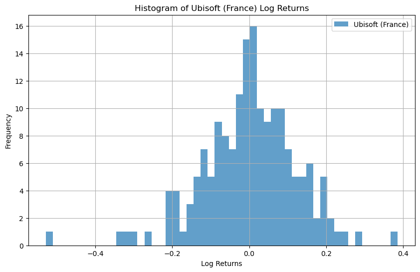

```python
import matplotlib.pyplot as plt

# Assuming stock_returns is already defined and contains the log returns for each stock

# Set the number of bins for the histogram
bins = 50

# Iterate through each column in the stock_returns DataFrame
for column in stock_returns.columns:
    plt.figure(figsize=(10, 6))  # Create a new figure for each histogram
    plt.hist(stock_returns[column].dropna(), bins=bins, alpha=0.7, label=column)
    plt.title(f'Histogram of {column} Log Returns')
    plt.xlabel('Log Returns')
    plt.ylabel('Frequency')
    plt.legend()
    plt.grid(True)
    plt.show()
```

```python
stock_returns.corr()
```

|  | Tecent (China) | Sony (Japan) | Electronic Arts (USA) | Ubisoft (France) |
| --- | --- | --- | --- | --- |
| Tecent (China) | 1.000000 | 0.338676 | 0.281475 | 0.394269 |
| Sony (Japan) | 0.338676 | 1.000000 | 0.305214 | 0.288814 |
| Electronic Arts (USA) | 0.281475 | 0.305214 | 1.000000 | 0.365324 |
| Ubisoft (France) | 0.394269 | 0.288814 | 0.365324 | 1.000000 |

## Calculates and displays the correlations of log stock returns between each company.

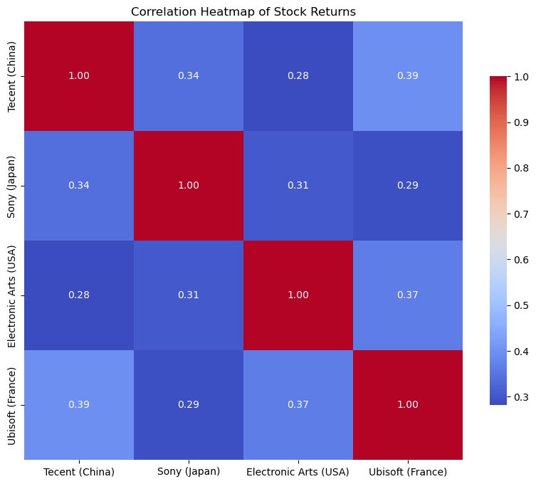

```python
import seaborn as sns
import matplotlib.pyplot as plt

# Calculate the correlation matrix for the stock_returns DataFrame
corr_matrix = stock_returns.corr()

# Set up the matplotlib figure
plt.figure(figsize=(10, 8))

# Draw the heatmap with the mask and correct aspect ratio
sns.heatmap(corr_matrix, annot=True, cmap='coolwarm', fmt='.2f',
            xticklabels=corr_matrix.columns, yticklabels=corr_matrix.columns,
            cbar_kws={"shrink": .75}, square=True)

# Add a title
plt.title('Correlation Heatmap of Stock Returns')

# Show the plot
plt.show()
```